# Fiji NFMS ER Calculations Summary

David Chambers, Carly Green, Michael Green

May 2021

# 1. Introduction

## 1.1 Purpose of Document

This document describes the Fijian Ministry of Forestry approach to calculating annual emissions and removals from REDD+ Activities and estimation of Emission Reductions using R language for World Bank Forest Carbon Partnership Facility (FCPF) Carbon Fund Monitoring Report.

The document:

- Outlines the parameters and outputs of functions used to calculate the emissions and removals from REDD+ Activities;
- References the R script functions used to calculate the outputs required for the FCPF monitoring report;
- Discusses the outputs from the R calculations with reference to their values, associated uncertainty and sensitivity analysis,
- Provides guidance on modification of the code for a change in methodology or adoption of a new data set;
- Provides information/code for the packages used to complete the calculations.

The source code covered in this documentation forms part of the Fiji Information Management System (FIMS). These calculations within the code will be run as part of normal operations of the FIMS. FIMS will manage the operational requirements which consists of ensuring the correct inputs to the code and recording of the outputs. This code is provided in this format so as to facilitate the management of updates, testing, and sharing the code with third parties without the need to establish a correctly installed and operational instance of the FIMS system.

## 1.2 Audience

There are three main audiences for this document. Each group is listed below with the intended outcomes for that audience.

The Ministry of Forestry Staff:

- Be able to make changes to the calculations based on methodology changes;
- Find the code that implements calculations for review and auditing of processes;
- Communicate to third parties to enable improvements

Consultants:

- Be able to make changes to the calculations based on methodology changes;
- Find the code that implements calculations for review and auditing of processes;
- Be able to efficiently and consistently update documentation following changes made

Auditors and Reviewers:

- Be able to find code that implements calculations for review and auditing;

## 1.3 Terminology

### Code Naming Convention

The names used in identifiers (functions, objects, values, …) are based on the following style:

Scope::Usage::Type::Name

| Scope | Usage | Type | Name |
| --- | --- | --- | --- |
| Calc | Est | Em | e.g Defor |
| Mp | Net | Rem |  |
| Rp | Gross | EmRems |  |
| Erpa | Current | ERs |  |
|  | Previous | FRL |  |
|  | Transferred | EF |  |
|  | Adj |  |  |
|  | Contested |  |  |
|  | Sold |  |  |

Each field (Scope, Usage, Type, Name) can have the following:

Scope:

- **Calc**: A calculation function returning a result. This will generally have the units of CO<sub>2</sub>e.
- **Mp**: Monitoring Period. These values and data are for the whole Monitoring Period.
- **Rp**: Reporting Period. These values and data are pro rata values of the equivalent MP data and is determined as the ratio of the Reporting Period to the Monitoring Period
- **Erpa**: ERPA value which relates to the whole Program Period.

Usage:

- **Est**: An estimate of the data
- **Net**: A sum of estimates which have a -ve and +ve range
- **Gross**: A estimate which has not been adjusted or reduced by the opposite estimates. For example emission from Forest Degradation without considering removals.
- **Previous**: A running total of the value across all reports but does not include this reports estimates.
- **Current**: The running total value which takes in to consideration all previous report values as well as the current report estimates.
- **Transferred**: The Emissions Reductions which have been transferred prior to this reporting period.
- **Adj**: Values which have been adjusted for buffers.
- **Contested**: Contested Emissions Reductions
- **Sold**: The Emissions Reductions which have been sold prior to this reporting period.

Type:

- **EF**: A emission factor used in calculations
- **Em**: A value representing an emission of CO<sub>2</sub>e, always positive (+ve).
- **Rem**: A value representing an removal of CO<sub>2</sub>e, always negative (-ve).
- **EmRem**: A value that represents a -ve (removal) or +ve (emission) of CO<sub>2</sub>e.
- **ERs**: A value that represents a +ve (reduction) or -ve (reversal) as compared to the ERPA Forest Reference Level.
- **FRL**: A value that represents the Forest Reference Level or a sub activity of the Forest Reference Level

Name:

The following are examples of names and abbreviations used.

- `EstEmRemsDefor`: is an estimate (Est) of emission/removals (EmRems) for deforestation (Defor)
- `MpEstFRL`: is the specific Monitoring Period (Mp) estimate (Est) of the Forest Reference Level (FRL)
- `ErpaPreviousERs`: is the ERPA (Erpa) running total not including the Monitoring Period of the report (Previous) of the Emission Reductions (ERs)

Other shortened words used are:

- `Enh`: Enhancements, i.e. sinks.
- `FDeg`: Forest Degradation.

### Acronyms

- [] Todo: some Acronyms are being replaced. This list will need to be updated on completion.

| Acronym | Meaning |
| --- | --- |
| AD | Activity Data |
| AGB | Above Ground Biomass |
| AR | Afforestation/Reforestation |
| Args | Arguments |
| BCEF | Biomass Conversion and Expansion Factor |
| BGB | Below Ground Biomass |
| Conv | Conversion |
| DF | Deforestation |
| Defor | Deforestation |
| EF | Emissions Factor |
| ER | Emission Reduction |
| ERPA | Emission Reductions Program Agreement |
| Em | Emissions |
| Est | estimate |
| FD | Forest Degradation |
| FDeg | Forest Degradation |
| FP | Forest Plantation |
| FRL | Forest Reference Level |
| Fell | Felling |
| ForPlant | Forest Plantation |
| GHGS | Greenhouse Gases |
| HW | Hardwood |
| Harv | Harvested |
| Inc | Increment |
| LCI | Lower Confidence Interval |
| MAIAGB | Mean Annual Increment of Above Ground Biomass |
| MAIB | Mean Annual Increment of Biomass |
| MAIC | Mean Annual Increment of Carbon |
| MAIV | Mean Annual Increment of Volume |
| MC | Monte Carlo |
| Plant | Planted |
| Rem | Removals |
| SD | Standard Deviation |
| SW | Softwood |
| Stock | Stocked |
| TEF | Total Emissions Factor |
| Trop | Tropical |
| UCI | Upper Confidence Interval |
| Vol | Volume |
| err | Error |
| ha | hectare |
| m3 | cubic metre |
| tCO2e | Tonne of Carbon dioxide equivalent |
| yr | year |
| yrs | years |

## Preliminaries

### Source Code

The source code for the Fiji NFMS Integration framework is separated into a set of drivers and a set of support packages.

Access to the repository is by invitation only.

- [] Todo: Add contact details: info@enviroaccounts.com

**Drivers**

The drivers are all in a single repository [github::micko920/FijiNFMSIntegration](https://github.com/micko920/FijiNFMSIntegration). They provide the front end execution interface for running the calculations.

**Packages**

The support code is subdivided into packages based on functionality. They need to be installed into the R session before the drivers and tests will execute successfully.

They can be installed with the following commands:

```
devtools::install_github("micko920/ValueWithUncertainty")
devtools::install_github("micko920/FijiNFMSCalculation")
devtools::install_github("micko920/MonteCarloUtils")
```

### Dependencies and R Session Information

These packages can be installed by using the `requirements.R` file in the drivers code repository [github::micko920/FijiNFMSIntegration](https://github.com/micko920/FijiNFMSIntegration).

# 2. R Script Calculations

This section describes the calculations carried out by the R Script to produce the required values for the FCPF Carbon Fund Monitoring Report. Details and justifications for the adopted calculation methodology are available in a separate document titled *REDD+ Calculation Methodology: Fiji*. Relevant sections of this document are referenced against each of the following sub-sections should more methodological detail be required.

## 2.1. REDD+ Activities Annual Estimations

Emissions and removals from REDD+ Activities reported in Fiji fall under the categories of Deforestation, Forest Degradation and Enhancements.

### 2.1.1. Deforestation

**Scope**

Deforestation is defined as the conversion of land in the land-use sub-category Natural Forest (low- or upland) to land in the sub-category non-forest. Deforestation occurs if the crown-cover percent on a patch of land (min. 0.5 ha) drops below the threshold value of 10%. Deforestation cannot occur within lands previously defined as plantations as this land is classified as Forest Land regardless of canopy cover as it primary land use is forest.Emissions from deforestation from lowland and upland natural forest, excluding areas subject to logging in Fiji.Areas of forest loss detected in annual remotely sensed images are combined with data on carbon stocks in defined strata, both of the pre- and post land cover class (e.g. Pre deforestation land cover class of Lowland forest and post deforestation class of Grassland).

Annually monitored activity data which drive these estimates include:

- areas of deforestation detected in remotely sensed data.

**Reference**

- Methodology: Fiji REDD+ Calculation Methodology - Section 3
- Package: `FijiNFMSCalculations`
- Script: `Deforestation.R`

**Prior Requirements**

- [] Todo: Data: Hectares of Area Deforested in lowland an upland natural forest.

**Output**

This emissions source provides a contribution to the overall emission/reduction estimate from REDD+ Activities in Fiji. This value is required for reporting and further calculation of values in the FCPF Monitoring Report.

### 2.1.2. Forest Degradation

Emissions from forest degradation are estimated as the combination of the net emissions/removals from logging in Natural Forests and the emissions from Fire in Pine Plantations.

#### Felling

**Scope**

Emissions related to felling practices in natural forest are estimated using the approach proposed by Pearson et al. (2014). This methodology includes losses from felling operations, including loss from the felled tree itself (AGB and BGB), logging residues of the felled tree, felling damages to the remaining stand (AGB and BGB), and losses due to the establishment of felling infrastructure (e.g., skid trails, roads and log landings).

Annually monitored activity data which drive these estimates include:

- recorded volumes of wood extracted to drive estimates of emissions from extraction
- area subject to felling activities to drive estimates of removals from regrowth

The net of estimates of emissions from felling and removals from regrowth provide an annual estimate of emissions/removals from felling activities in natural forest.

**Reference**

- Methodology: Fiji REDD+ Calculation Methodology - Section 4.1
- Package: `FijiNFMSCalculations`
- Script: `Felling.R`

**Prior Requirements**

- [] Todo: Data

**Output**

This emissions source provides a contribution to the overall emission/reduction estimate from REDD+ Activities in Fiji. This value is required for reporting and further calculation of values in the FCPF Monitoring Report.

#### Emissions from Fire

**Scope**

Emissions from fire are estimated from burnt areas in Softwood Plantations (Pine) owned and managed by Fiji Pine Limited. The methodology estimates carbon dioxide (CO<sub>2</sub>), methane (CH<sub>4</sub>) and nitrous oxide (N<sub>2</sub>O) emissions from biomass available for combustion in a compartment and combustion factors combined with specific characteristics of burnt areas.

Annually monitored data which derive these estimates include: - year of burning (year); - area burnt in hectares (ha); - age in years (yrs) of each burnt area (i.e., the time elapsed since planting).

**Reference**

- Methodology: Fiji REDD+ Calculation Methodology - Section 4.2
- Package: `FijiNFMSCalculations`
- Script: `Burning.R`

**Prior Requirements**

- [] Todo: Data

**Output**

This emissions source provides a contribution to the overall emission/reduction estimate from REDD+ Activities in Fiji. This value is required for reporting and further calculation of values in the FCPF Monitoring Report.

### 2.1.3. Enhancements

Enhancement of forest carbon stocks includes removals from afforestation/reforestation, as well as net emissions and removals from the management of softwood and hardwood plantations.

#### Afforestation

**Scope**

Afforestation/Reforestation is defined as the conversion of land in the land-use sub-category Non-Forest to land in the sub-category Natural Forest (Low- or Upland) or Plantations (Softwood and Hardwood). Afforestation/reforestation occurs if the crown-cover percent on a patch of land (min. 0.5 ha) reaches or exceeds the threshold value of 10%. Afforestation/reforestation cannot occur within lands previously defined as plantations as this land is classified as Forest Land regardless of canopy cover as it primarily land use is forest. New plantations established on lands that have not previously been a forest are considered afforestation/reforestation. It is assumed that afforestation/reforestation always has anthropogenic causes in Fiji.

Annually monitored activity data which drive these estimates include:

- areas of regrowth detected in remotely sensed data

**Reference**

- Methodology: Fiji REDD+ Calculation Methodology - Section 5.1
- Package: `FijiNFMSCalculations`
- Script: `Afforestation.R`

**Prior Requirements**

- [] Todo: Data

**Output**

This emissions source provides a contribution to the overall emission/reduction estimate from REDD+ Activities in Fiji. This value is required for reporting and further calculation of values in the FCPF Monitoring Report.

#### Forest Plantations

**Scope**

Emissions and removals in tCO<sub>2</sub>e from Forest Plantation Management. This includes the growth and felling of Softwood and Hardwood plantation timber. By definition, deforestation and afforestation/reforestation is not possible within Forest Plantations. Forest Plantations remain in the land-use category Forest Land even if the crown-cover is completely removed following harvest, e.g., temporarily unstocked.

Estimates of emissions from Forest Plantations rely on annually collected records of extracted timber volumes. Estimates of removals rely on mean annual increment (MAI) and area stocked.

Annually monitored activity data which drive these estimates include:

- extracted volumes
- area stocked

**Reference**

- Methodology: Fiji REDD+ Calculation Methodology - Section 5.2
- Package: `FijiNFMSCalculations`
- Script: `ForestPlantations.R`

**Prior Requirements**

- [] Todo: Data

**Output**

This emissions source provides a contribution to the overall emission/reduction estimate from REDD+ Activities in Fiji. This value is required for reporting and further calculation of values in the FCPF Monitoring Report.

### 2.1.4. Annual Net Emissions/Removals from REDD+ Activities

**Scope**

Annual net Emissions/Removals represent the summation of emissions and removals from the REDD+ activities: Deforestation, Forest Degradation and Enhancements for one year.

**Reference**

- Methodology Fiji REDD+ Calculation Methodology - Section 6
- Package: `FijiNFMSCalculations`
- Script: `EmissionReductions.R`

**Prior Requirements**

Calculation of all REDD+ activities (Deforestation, Forest Degradation, Enhancements)

**Output**

The values of net emissions and removals are reported in the FCPF Monitoring Report and are used to calculate Emissions Reductions against the Forest Reference Level (FRL)

## 2.2. Emission Reductions

Emission Reductions represent the change in emissions during a specified Monitoring Period when compared to the Forest Reference Level.

**Scope**

Emission Reductions are calculated as the difference between the Forest Reference Level (an average to annual emissions/removals from all included REDD+ Activities between 2006 - 2016) and the calculated annual average emissions/removals during the Monitoring Period minus any required risk/uncertainty buffer deductions.

**Reference**

**Prior Requirements**

Forest Reference Level (FRL) from Fiji Ministry of Forestry Net Emissions/Removals value for the monitoring period.

**Output**

The value of Emission Reductions is reported in the FCPF Monitoring Report.

## 2.3. Outputs for FCPF Monitoring Report

**Scope**

The outputs from the R script calculation are used to populate the FCPF Monitoring report for a specified Reporting Period. In particular Tables 4.2, 4.3, 5.2.2, 7.2 and 8 of the ER Monitoring Report Template are populated from the outputs of this R Script.

**Reference**

- Methodology: Fiji REDD+ Calculation Methodology - Section 9
- Package: `FijiNFMSIntegration`
- Script: `Funcs/TableCreationFunction.R`

**Prior Requirements**

Calculation of all REDD+ activities (Deforestation, Forest Degradation, Enhancements), Emissions Reductions and net emissions/removal values.

**Output**

Values to be reported in the FCPF monitoring report including Tables 4.2, 4.3, 5.2.2, 7.2 and 8.

# 3. Discussion

This section provides has some high-level design details and instruction for using the packages. For more detail please refer to the internal documentation for each package.

This section includes:

- **Script Parameters**: Parameters and data that control how the R Script executes
- **Drivers**: Details on executing a specific set of calculations to produce a subset output for the Monitoring Report
- **Modification of the Code**: Modular code may be replaced or require updating as the context and methodology is updated.
- **Testing and Unit Testing**: Confirmation that the code is operating correctly

## 3.x. Script Parameters

### Monitoring Report Parameters

- [] Todo: Add detail about Report Parameters - CG

### Monitored Values

- [] Todo: Add detail about Monitored Values - CG

### Burn Data

- [] Todo: Add detail about Burn Data - CG

## 3.1. Drivers

The drivers provide a way to execute the calculations and generate specific output for the Monitoring Report. They have been broken up based on the execution time to produce the output.

The 3 drivers are:

- Values: Performs the calculations to produce basic emissions and removals and gross emission reduction calculations without uncertainty or adjustments or running totals.
- Uncertainty: Performs the basic value calculations with uncertainty propagation.
- Sensitivity: Performs sensitivity analysis of parameters on the uncertainty of the final calculations.

Each driver has three forms of output:

- Console: simple execution messages to show that the code is running. It may output some values when complete.
- Text file: The drivers will write important calculated values to a text file with the name of the driver. This output is captured for testing and automation processes.
- R session environment: The drivers will populate variables in the global environment as part of the their execution. These values can be explored via RStudio or saving the RData file after executing the driver in a R session.

See individual driver sections for specific purpose and outputs.

### Guidance: Opening and Running a Driver

- Open R Studio

[figure not shown]

- Set working directory to file directory

[figure not shown]

- Open Driver file

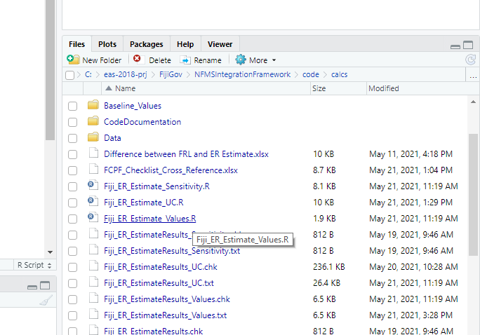

- Run file (Ctrl+alt+r, through code menu or on console source(“./driverfilename.R”))

[figure not shown]

- Check the outputs in the environment.

[figure not shown]

- Check the outputs in the console.

[figure not shown]

For more guidance on using RStudio please refer to the RStudio website [RStudio Support](https://support.rstudio.com/hc/en-us)

### 3.1.1. Values

**Purpose**

The Values driver produces estimates without uncertainty. These calculations are quick to run but only provide the following results for the Monitoring Report:

- Yearly EmRems
- Monitoring Period Gross ERs
- Reporting period Emission Reduction Program Agreement (ERPA) balance of ERs.

The same calculations are then used by the Value with Uncertainty Driver and the Sensitivity Analysis Driver.

**Output**

- `EmRems_Values`: Emission and removals estimates
- `ER_Values`: Potential ERs before deductions or buffering
- `MR_Values`: Monitoring Report Values used to create table output

Produces Tables 4.2, 4.3 for the FCPF Monitoring Report. - `Table4_2` - `Table4_3`

### 3.1.2. Values with Uncertainty

**Purpose**

The Values with uncertainty driver provides estimates with uncertainty for the Monitoring Period data and the Emission Reductions available for transfer to the Carbon Fund. This driver uses the estimation calculations in multiple layers of Monte Carlo Simulations. The values used in the calculations have a modeled uncertainty. The Monte Carlo simulations are used to produce an upper and lower values of the confidence interval for the calculations.

The values and the associated uncertainty models used in the calculations are encapsulated in an R Object called ValueWithUncertainty. This object is detailed in the package of the same name.

- [] Todo: Reference the ValueWithUncertainty package and documentation.

The purpose of using this R Object encapsulation was to ease the process of selectively turning the uncertainty off and on for individual values used in the calculations.

Each ValueWithUncertainty R Object can either be a numeric value as a result of sampling the model of variation or it can be the ‘fixed’ estimate. When the object is fixed all references to the object will return a fixed numeric value which was the original estimated value.

When sampling is enabled the reference to the value will return a sampled value with the probability based on the model associated with the values uncertainty. This allows the code to remain consistent for both straight line calculations where no uncertainty is considered and calculations with uncertainty of all variables considered, as well as combinations of both. See the section on sensitivity analysis.

**Propagation of uncertainty using Monte Carlo Simulations:**

- [] Todo: Reference the Monte Carlo Utils package and documentation.

The uncertainty of the values and the results of the calculations are propagated through to the final estimate via Monte Carlo simulation techniques.

Each time a Monte Carlo simulation is performed the results are captured in a ValueWithUncertainty R Object. This allows the value and the model to be used in subsequent calculations and Monte Carlo simulations. The probability distribution model used to represent the Monte Carlo calculation results is a sample of samples model, i.e. a bootstrap. The sample of samples model uses the results of the Monte Carlo simulation as the source of values which it then samples uniformly.

The Monte Carlo simulation uses a algorithm with an internal stopping condition based on either a limit of the number of iterations or the stabilisation with tolerance of the 90% CI, Which ever happens first. If the 90% CI stabilises with a specified tolerance the simulation is stopped. Otherwise the simulation continues until the number of interactions is reached.

The stabilisation condition of the 90% CI was used as it directly affects the range of the uncertainty. Stabilisation of the mean happens relatively early with some calculations in the simulation while the confidence interval may be still unstable. If the smaller set of results are used as the model of uncertainty for the calculation it could cause bias or inaccurate ranges of uncertainty which will affect further propagation.

Using this stopping algorithm allows the Monte Carlo simulation the opportunity to complete as early as possible when a calculation is relatively stable rather than doing repeated unnecessary iterations. See the package documentation for more details on this algorithm. This is important for the sensitive analysis as some values become fixed and so do not need the same number of runs to propagate the uncertainty effectively. This stopping algorithm automatically reduces execution time dramatically.

The method of iteration used in the Monte Carlo simulation is the `replicate` function. This was used as it is orders of magnitude faster than a `for` loop and a little more convient than the apply functions. The function could be replaced with multi core equivalents, but the issues of statistically sound parallel random number generation would need to be taken into consideration. This was deamed as unnessary in the context of the size of the data and number of iterations required.

To control the Monte Carlo iterations there are two parameters set at the start of the script.

- `MCRuns`: (Default: 1.5e+06) the limit the number of runs in MC simulation
- `MCTolerance`: (Default: 0.01) how stable the UCI and LCI should be before stopping

The default values above will have an execution time of about 1 min on the single core such as a Intel i7-7700HQ CPU @ 2.80GHz, with around 1.0e+4 iterations per Monte Carlo simulation.

Reducing the `MCTolerance` to 0.0025 will mean the excution time will take in the order of 10mins, with around 1.5e+5 iterations per Monte Carlo simulation.

Changing the `MCRuns` to a higher number will not enforce more iterations. The `MCTolerance` will also need to be reduced.

The simulations can be visualised by enabling `plot_mc_output`. Setting this value to `TRUE` will plot the results of the Monte Carlo simulations and the stopping algorithm data.

The 4 plots produced are:

- A frequency plot of the samples produced in the Monte Carlo simulation.
- A box chart of the samples with points marked for the 90% CI and the estimate.
- A log graph of standard deviations assessments of the width of the 90% CI for the MC samples over the increasing number of Monte Carlo iterations.
- A log graph of the 90% CI at each stopping assessment.

It can be seen in a number of plots that the CI changes as the number of interations are increased. Also it can be seen in the boxcharts the estimate appearing to lie in the extreams of the unceratinaty. This is being investigated.

**Independent, Partially, and Shared sources of uncertainty:**

Some calculations share a dependence on common values with an associated uncertainty. The results from these calculations are then used in further calculations which will result in a combination of independent (zero correlation) sources of uncertainty, partially (mixed correlation) dependent sources of uncertainty, and shared (fully correlated) sources of uncertainty.

The FCPF guidance warns against treating all sources of uncertainty as independent. This will underestimate the interactions of the shared and partially shared uncertainty with other input variables in related calculations.

The suggested solution is to use a single sample of the value based on the uncertainty for all calculations conducted in a single simulation. This will then ensure that the interdependence and effect of the uncertainty is correctly carried through the whole simulation and final estimates.

The Fiji calculations did not use this method. To mitigate the effects of the shared and partially shared sources of uncertainty the Monte Carlo simulations are done at a number of calculation levels to propagate the uncertainty to other related calculations.

This has the effect of ‘exercising’ the full range of the uncertainty for all shared and partially shared sources of uncertainty for all calculations completely.

**Output**

- `EmRems_Values`: Emission and removals estimates.
- `ER_Values`: Potential ER’s before deductions or buffering.
- `MR_Values`: Monitoring Report Values used to create table output.
- `ResultsTables`: This table is a ‘replica’ of the original FRL table generated for Fiji. It allows some lower lever reporting for internal stakeholders.
- `UC_Values`: The ValueWithUncertainty models for the Emission Factors and other default input parameters.
- `UC_MV_Values`: The ValueWithUncertainty models for the Monitored Values.
- `UC_EmRems_Values`: The confidence intervals, Monte Carlo results for the Emissions Removal estimates.
- `UC_ER_Values`: The confidence intervals, Monte Carlo results, and Half Width, relative margin and conservative factors for the Emissions removals estimates.

Produces Tables 4.2, 4.3, 5.2.2, 7.2 and 8 for the FCPF Monitoring Report. - `Table4_2` - `Table4_3` - `Table5_2_2` - `Table7_2` - `Table8`

### 3.1.3. Sensitivity Analysis

**Purpose**

The Sensitivity Analysis produces a report which assesses the Total Effect Index of parameters for which uncertainty is included in the calculations. Not all parameters and sources of uncertainty are assessed.

- [] Todo: Reference Uncertainty list and list of assessed parameters.
- [] Todo: Reference (Word document with value with uncertainty defined) either in CG document (link) or coding table with parameter and code name……..

The Fiji Code uses the Total Effect Index method for ranking the parameters effects on the overall uncertainty. The ranking of the parameters allows prioritizing improvements to those which will have the biggest impact to reducing the overall uncertainty.

This method has been implemented from guidance provided from the FCPF.

- [] Todo: Reference World Bank UC guidance document received from Rama
- [] Todo: Reference World Bank UC Power Point presentation from Andres

The following description provides a basis for explaining design decisions related to the implementation of the Sensitivity Analysis. More information about the implementation and the algorithm can be found in the package documentation.

**Total-effect index:**

- [] Todo: Needs more work, this was extracted from wiki pages. But provides the knowledge needed to understand the results!! [Wikipedia_Sensitvity_Analysis]:https://en.wikipedia.org/wiki/Sensitivity_analysis [Wikipedia_Variance_Based_Sensitvity_Analysis]:https://en.wikipedia.org/wiki/Variance-based_sensitivity_analysis [Python_Sensitvity_Analysis]:https://uncertainpy.readthedocs.io/en/latest/theory/sa.html

*First-order indices*

A direct variance-based measure of sensitivity S<sub>i</sub>, called the “first-order sensitivity index”, or “main effect index” is stated as follows,[1]

$$S_{i}={\frac {V_{i}}{\operatorname {Var}(Y)}}$$

This is the contribution to the output variance of the main effect of X<sub>i</sub>, therefore it measures the effect of varying X<sub>i</sub> alone, but averaged over variations in other input parameters. It is standardised by the total variance to provide a fractional contribution. Higher-order interaction indices S<sub>ij</sub>, S<sub>ijk</sub> and so on can be formed by dividing other terms in the variance decomposition by Var(Y). Note that this has the implication that,

$$\sum _{{i=1}}^{d}S_{i}+\sum _{{i<j}}^{{d}}S_{{ij}}+\cdots +S_{{12\dots d}}=1$$

Using the S<sub>i</sub>, S<sub>ij</sub> and higher-order indices given above, one can build a picture of the importance of each variable in determining the output variance. However, when the number of variables is large, this requires the evaluation of 2d-1 indices, which can be too computationally demanding. For this reason, a measure known as the “Total Effect index” or “Total Order index”, S<sub>Ti</sub>, is used.[2] This measures the contribution to the output variance of X<sub>i</sub>, including all variance caused by its interactions, of any order, with any other input variables. It is given as,

$$S_{Ti}=\frac {E_{{\textbf {X}}_{\sim i}}\left(\operatorname {Var}_{X_{i}}(Y\mid \mathbf {X}_{\sim i})\right)}{\operatorname {Var} (Y)}=1-\frac {\operatorname {Var}_{{\textbf {X}}_{\sim i}}\left(E_{X_{i}}(Y\mid \mathbf {X}_{\sim i})\right)}{\operatorname {Var} (Y)}$$

Note that unlike the S<sub>i</sub>,

$$\sum_{{i=1}}^{d}S_{{Ti}}\geq 1$$

due to the fact that the interaction effect between e.g. X<sub>i</sub> and X<sub>j</sub> is counted in both S<sub>Ti</sub> and S<sub>Tj</sub> In fact, the sum of the S<sub>Ti</sub> will only be equal to 1 when the model is purely additive.

[1] Sobol’, I. (1990). Sensitivity estimates for nonlinear mathematical models. Matematicheskoe Modelirovanie 2, 112–118. in Russian, translated in English in Sobol’ , I. (1993). Sensitivity analysis for non-linear mathematical models. Mathematical Modeling & Computational Experiment (Engl. Transl.), 1993, 1, 407–414.

[2] Homma, T. and A. Saltelli (1996). Importance measures in global sensitivity analysis of nonlinear models. Reliability Engineering and System Safety, 52, 1–17.

*Fiji Method:*

The sensitivity value selected for Fiji is the S<sub>Ti</sub>, the Total Effect Index of X<sub>i</sub>.

This sensitivity value was selected to be reported for variables as it will have larger values for S<sub>Ti</sub> (approaching 1) being candidates, rather than smaller (approaching 0) values, for reducing overall variance and therefore uncertainty of the estimate calculations.

The total effect index of X<sub>i</sub> is given by the following equations:

$$S_{Ti}=\frac {E_{{\textbf {X}}_{\sim i}}\left(\operatorname {Var} _{X_{i}}(Y\mid \mathbf {X}_{\sim i})\right)}{\operatorname {Var} (Y)}=1-\frac {\operatorname {Var}_{{\textbf {X}}_{\sim i}}\left(E_{X_{i}}(Y\mid \mathbf {X}_{\sim i})\right)}{\operatorname {Var} (Y)}$$

As the effect of the uncertainty of X<sub>i</sub> gets larger the $Var_{X_{~i}}$ gets smaller so the remaining variance approaches 1.

- $Var_{X_{\sim i}}$: Variance of Y without the variance of X<sub>i</sub>, X<sub>i</sub> is held at its nominal value
- ${\operatorname {Var} (Y)}$: variance of the Y model including the variance on all variables.
- $S_{Ti}$: Contribution of the uncertainty of X<sub>i</sub> to the total variance

The second form of the equation was used:
$$S_{Ti}=1-\frac {\operatorname {Var}_{{\textbf {X}}_{\sim i}}\left(E_{X_{i}}(Y\mid \mathbf {X}_{\sim i})\right)}{\operatorname {Var} (Y)}$$

In other words, the contribution of the variance of X<sub>i</sub> standardised by the total variance is equal to 1 minus the variance of the final estimate calculation with the value of X<sub>i</sub> fixed divided by the variance of the original estimate calculation including the uncertainty of all variables.

Note: The sum of S<sub>Ti</sub> for all variable analysed will not equal 1. So a percentage will not be reported, just a fraction without a unit.

**Output**

- `TEI_Values`: The Total Effect Index values for each assessed parameter.

Produces a table which is used in section 5.3 Sensitivity Analysis of the FCPF Monitoring Report.

## 3.2. Modification of Code

- [] Todo: Code Modification needs work

There are a couple of use cases which may require the modification of the code:

1. Fiji methodological changes requires code to be updated/reviewed
2. Another country adopts the calculation code
3. Monitoring Period Report Tasks for new FCPF Report

The following sections provides guidance on how to perform these changes for these use cases.

### 3.2.1. Resulting from changes to Methodology

- If a default parameter is changed, the relevant parameter file will need to be updated.
- If a calculation equation is changed, the relevant calc file will need to be updated.
  - Associated Test documents will need to be updated
- New calculations or activities will need to be added to the `FijiNFMSCalculations` package and the drivers files.

### 3.2.2 Adoption of code for a new country context

- Country specific default parameters will need to be updated,
- Calculations in `FijiNFMSCalculations` Package to be reviewed and updated for the new countries activities and saved as a new package.
  - New calculations package should be referenced in the drivers files in EmRem, ER and data list sections.

### 3.2.3 Monitoring Period Report Tasks for new FCPF Report

- [] Todo: add detail - Monitoring Values files need to be updated for each new FCPF monitoring report.
  - This can be done in two ways:
    1. directly in the code files
    2. via FIMS

Each updating method depends on the updating party. Updating directly in the code is useful in the case where the code can be sent to an external party who does not have access to the FIMS.

- [] Todo: Add reference - See FIMS manual for editing in the FIMS. Link to manual- which will be saved in the FIMS.pdf

## 3.3. Testing & Unit Testing

Unit testing is written for all packages. Each test set includes some examples which have been drawn from the Fiji data. These are run using the `testthat` package.

Example of running the tests at the R prompt:

```
devtools::test()
```

See `?testthat` for more information.

There are also `chk` files. These files are the captured output of the drivers with a known set of inputs. These inputs are provided in the `Data/preMonitoringReport` directory. These values are mock data derived from Fiji data.

The output of a driver can be compared with the `chk` file to check weather the output is normal. Below is an example of unix commands that will perform this test:

```
    Rscript -e 'source("./fiji_frl_all_R_code.R")'
    diff -U 1  ./Fiji_FRL_Results.txt ./Fiji_FRL_Results.chk
    Rscript -e 'source("./Fiji_ER_Estimate_Values.R")'
    diff -U 1  ./Fiji_ER_EstimateResults_Values.chk ./Fiji_ER_EstimateResults_Values.txt
    Rscript -e 'source("./Fiji_ER_Estimate_UC.R")'
    diff -U 1  ./Fiji_ER_EstimateResults_UC.chk ./Fiji_ER_EstimateResults_UC.txt
    Rscript -e 'source("./Fiji_ER_Estimate_Sensitivity.R")'
    diff -U 1  ./Fiji_ER_EstimateResults_Sensitivity.chk ./Fiji_ER_EstimateResults_Sensitivity.txt
```

Any code changes should be reflected in associated tests to ensure that the quality of code is maintained.

**Note:**

Some of the tests use a `set.seed(number)` with an arbitrary number to ensure that the tests are repeatable when using random number generation. The seed is not required in the normal operation of the code.

# 4. Packages

## Fiji NFMS Calculations

- [] Todo: Reference Package Documentation

The basic estimation calculations based on the methodology.

## Value with Uncertainty

- [] Todo: Reference Package Documentation

The R Object to encapsulate a value with an uncertainty model. These objects are used in uncertainty propagation and sensitivity analysis.

## Monte Carlo Utils

- [] Todo: Reference Package Documentation

Utilities to run Monte Carlo simulations for a calculation function from the Fiji NFMS calculations against a set of arguments.

## FCPF Monitoring Report Tables

- [] Todo: Reference Package Documentation
- [] Todo: separate FCPF Monitoring Report Table functions (currently in ../Funcs/TableCreationFunctions.R) into their own package.